# Manufacturing places in London

*libraries*

```r
library(ggplot2)
library(ggthemes)
library(gridExtra)
library(knitr)
library(htmlTable)
library(readr)
library(sp)
library(rgeos)
library(tmap)
library(tmaptools)
library(sf)
library(rgdal)
library(geojsonio)
library(spData)
library(tidyverse)
library(maptools)
library(RColorBrewer)
```

# 1 Problem

Identify zones outside the Industrial Land Designation areas with high concentration of manufacturing, other economic activities and residences.

# 2 Context

We have analysed 3 open data datasets refering to Manufacturing in London.

```r
sT <- data.frame(Name, Source, Observation, General_Desc, Version)
htmlTable(sT, rnames=F, align="l", col.columns = c("none", "#F7F7F7"), css.cell="padding:1em")
```

| Name | Source | Observation | General_Desc | Version |
| --- | --- | --- | --- | --- |
| Directory of London Businesses - UK Standard Industrial Classification (SIC) | London Data Store (1) | “Data snapshot containing basic company data of live companies on the register. Each entry represents a financial accounts submission of either a whole company or part of one. Some businesses have mor… | Point data, N = 1,130,474 obs. | May 2018 |
| Business Register and Employment Survey - BRES | NOMIS - Official Labour Market Statistics ONS (2) | “An employer survey of the number of jobs held by employees broken down by full/part-time and detailed industry (5 digit SIC2007)” | Estimated number of jobs per LSOA (N = 4,835 obs.) Includes Industry percentage (percentage of jobs in Manufacturing) (3) | 2017 (latest data) |
| Inter Departmental Business Register (IDBR) | NOMIS - Official Labour Market Statistics ONS | “An extract recording the number of local units that were live at a reference date in March. Estimates can be broken down by employment size band, detailed industry (5 digit SIC2007) and legal status.… | Number of workplaces per MSOA (N = 983 obs.) (4) | 2018 (latest data) |

URLs:  
1 https://data.london.gov.uk  
2 https://www.nomisweb.co.uk/  
3 https://www.ons.gov.uk/employmentandlabourmarket/peopleinwork/employmentandemployeetypes/bulletins/businessregisterandemploymentsurveybresprovisionalresults/provisionalresults2017revisedresults2016#quality-and-methodology  
4 https://www.ons.gov.uk/aboutus/whatwedo/paidservices/interdepartmentalbusinessregisteridbr https://www.ons.gov.uk/businessindustryandtrade/business/activitysizeandlocation/methodologies/ukbusinessactivitysizeandlocationqmi

# 3 Cartographic summary

# 4 Analysis

A detailed analysis was carried out for the BRES dataset due to four reasons:

1. The number of manufacturing jobs obtained from the BRES dataset is considered the best proxy to represent manufacturing intensity. This measure can be interpreted as a combination of number of manufacturing units and size.
2. The level of detail of the BRES dataset at the LSOA area is considered sufficient to allow the selection of case study areas for micro-morphology analysis.
3. The SIC dataset despite having a finer-grain resolution has shown innacuracies in the location of the data points (reference: Vyner street case study Cites of Making project).
4. Despite the fact that the IDBR considers a larger sample at the national level, it is aggregated at a lower resolution geographic area (MSOA). Also, because according to a data methodological note “it is possible to get multiple business registrations at a single address and this can distort data for smaller geographical areas” (https://www.ons.gov.uk/businessindustryandtrade/business/activitysizeandlocation/methodologies/ukbusinessactivitysizeandlocationqmi/pdf).

## 4.1 Metadata

Data source: NOMIS official labour market statistics (ONS) URL: https://www.nomisweb.co.uk/  
Definition: *“An employer survey of the number of jobs held by employees broken down by full/part-time and detailed industry (5 digit SIC2007). The survey records a job at the location of an employees workplace. Available from country down to lower level super output area and Scottish datazone.”*  
Ref URLs: https://onsdigital.github.io/dp-classification-tools/standard-industrial-classification/ONS_SIC_hierarchy_view.html

Read NOMIS data. Lower Layer Super Output Area (2011)  
Industry Standard industrial classification of economic activities (SIC) 2007 section C: Manufacturing

```r
nom <- read_csv("/Volumes/ritd-ag-project-rd00lq-jamfe87/GIS_Analysis/dataProcessed/nomis_4835.csv") # 4,835 obs.
```

## 4.2 Data summary

```r
nom <- mutate(nom, lsoa11_cd = substr(lsoa_2011, 1, 9))
```

Summary of ‘nom’ Count and Industry percentage

```r
summary(nom)
```

```
##   lsoa_2011             Count         Industry percentage
##  Length:4835        Min.   :   0.00   Min.   :  0.000
##  Class :character   1st Qu.:   0.00   1st Qu.:  0.000
##  Mode  :character   Median :   0.00   Median :  0.000
##                     Mean   :  22.12   Mean   :  1.814
##                     3rd Qu.:  10.00   3rd Qu.:  1.400
##                     Max.   :6000.00   Max.   :100.000
##   lsoa11_cd
##  Length:4835
##  Class :character
##  Mode  :character
##
##
##
```

```r
nrow(table(nom$Count)) # [1] 34
```

```
## [1] 34
```

```r
dCount <-as.data.frame(table(nom$Count))
colnames(dCount) <-c("Jobs", "Frequency")
dCount1 <- cbind(dCount[1:10, ], dCount[11:20, ], dCount[21:30, ], dCount[31:40, ])
htmlTable(dCount1, rnames=F, caption="Jobs count frequency per LSOA (N = 4,835)", col.columns = c("none", "#F7F7F7"), css.cell="padding-left:1em; padding-right:1em;")
```

| Jobs count frequency per LSOA (N = 4,835) Jobs | Jobs count frequency per LSOA (N = 4,835) Frequency | Jobs count frequency per LSOA (N = 4,835) Jobs | Jobs count frequency per LSOA (N = 4,835) Frequency | Jobs count frequency per LSOA (N = 4,835) Jobs | Jobs count frequency per LSOA (N = 4,835) Frequency | Jobs count frequency per LSOA (N = 4,835) Jobs | Jobs count frequency per LSOA (N = 4,835) Frequency |
| --- | --- | --- | --- | --- | --- | --- | --- |
| 0 | 3052 | 50 | 72 | 350 | 9 | 1750 | 1 |
| 5 | 366 | 75 | 51 | 400 | 11 | 3000 | 1 |
| 10 | 539 | 100 | 53 | 450 | 2 | 4500 | 1 |
| 15 | 120 | 125 | 18 | 500 | 3 | 6000 | 1 |
| 20 | 151 | 150 | 34 | 600 | 11 |  |  |
| 25 | 60 | 175 | 8 | 700 | 6 |  |  |
| 30 | 75 | 200 | 14 | 800 | 4 |  |  |
| 35 | 33 | 225 | 6 | 900 | 4 |  |  |
| 40 | 57 | 250 | 21 | 1000 | 5 |  |  |
| 45 | 28 | 300 | 16 | 1500 | 2 |  |  |

Most LSOAs have 0 jobs in manufacturing. Among the rest the most frequent number is 10 jobs (in 539 LSOAs). High number of jobs ( > 1500) are an exception.

```r
table(nom[,3]) # 22 LSOA with 20% jobs in Manufacturing Industry
```

```
##
##    0  0.1  0.2  0.3  0.4  0.5  0.6  0.7  0.8  0.9    1  1.1  1.2  1.3  1.4
## 3105   17   51   47   42   38   45   41   48   13   60   31   72   11   42
##  1.5  1.6  1.7  1.8  1.9    2  2.1  2.2  2.3  2.4  2.5  2.7  2.8  2.9    3
##   12    2   86    3   12   71   11   27    7    1   82    5    5   45   25
##  3.1  3.2  3.3  3.5  3.6  3.8  3.9    4  4.2  4.3  4.4  4.5    5  5.6  5.7
##    3    2   96    3   13   13    4   56    3   10   12    3  102    7   12
##  5.8    6  6.2  6.4  6.7    7  7.1  7.5    8  8.3  8.6  8.8  8.9  9.4   10
##    5   14    9    2   81    3    4   16   26   16    4    3    1    1   69
## 10.7 11.1 11.2 11.4 11.7   12 12.5 12.9 13.3 13.9   14 14.3   15   16 16.7
##    2    3    4    2    3    9   16    2   12    2    1    3   12    2   18
## 17.5 17.8   18 18.8   20 20.8 21.4 22.2 22.9 23.3 23.7   24   25 26.7 27.8
##    1    1    2    7   22    1    1    2    1    1    1    3    6    7    1
##   28 28.6   30 33.3 34.3   35   36 37.5   40 41.7   50 53.3   60 66.7   70
##    1    1    6    9    1    1    1    1    3    2    4    1    2    1    1
##   75  100
##    1    1
```

```r
nrow(table(nom$`Industry percentage`)) # [1] 107
```

```
## [1] 107
```

```r
dInd <-as.data.frame(table(nom$`Industry percentage`))
colnames(dInd) <-c("Perc.", "Frequency")
dInd1 <- cbind(dInd[1:22, ], dInd[23:44, ], dInd[45:66, ], dInd[67:88, ], dInd[89:110, ])
htmlTable(dInd1, rnames=F, caption="Jobs Percentage frequency per LSOA (N = 4,835)", col.columns = c("none", "#F7F7F7"), css.cell="padding-left:1em; padding-right:1em;")
```

| Jobs Percentage frequency per LSOA (N = 4,835) Perc. | Jobs Percentage frequency per LSOA (N = 4,835) Frequency | Jobs Percentage frequency per LSOA (N = 4,835) Perc. | Jobs Percentage frequency per LSOA (N = 4,835) Frequency | Jobs Percentage frequency per LSOA (N = 4,835) Perc. | Jobs Percentage frequency per LSOA (N = 4,835) Frequency | Jobs Percentage frequency per LSOA (N = 4,835) Perc. | Jobs Percentage frequency per LSOA (N = 4,835) Frequency | Jobs Percentage frequency per LSOA (N = 4,835) Perc. | Jobs Percentage frequency per LSOA (N = 4,835) Frequency |
| --- | --- | --- | --- | --- | --- | --- | --- | --- | --- |
| 0 | 3105 | 2.2 | 27 | 5.7 | 12 | 12.5 | 16 | 26.7 | 7 |
| 0.1 | 17 | 2.3 | 7 | 5.8 | 5 | 12.9 | 2 | 27.8 | 1 |
| 0.2 | 51 | 2.4 | 1 | 6 | 14 | 13.3 | 12 | 28 | 1 |
| 0.3 | 47 | 2.5 | 82 | 6.2 | 9 | 13.9 | 2 | 28.6 | 1 |
| 0.4 | 42 | 2.7 | 5 | 6.4 | 2 | 14 | 1 | 30 | 6 |
| 0.5 | 38 | 2.8 | 5 | 6.7 | 81 | 14.3 | 3 | 33.3 | 9 |
| 0.6 | 45 | 2.9 | 45 | 7 | 3 | 15 | 12 | 34.3 | 1 |
| 0.7 | 41 | 3 | 25 | 7.1 | 4 | 16 | 2 | 35 | 1 |
| 0.8 | 48 | 3.1 | 3 | 7.5 | 16 | 16.7 | 18 | 36 | 1 |
| 0.9 | 13 | 3.2 | 2 | 8 | 26 | 17.5 | 1 | 37.5 | 1 |
| 1 | 60 | 3.3 | 96 | 8.3 | 16 | 17.8 | 1 | 40 | 3 |
| 1.1 | 31 | 3.5 | 3 | 8.6 | 4 | 18 | 2 | 41.7 | 2 |
| 1.2 | 72 | 3.6 | 13 | 8.8 | 3 | 18.8 | 7 | 50 | 4 |
| 1.3 | 11 | 3.8 | 13 | 8.9 | 1 | 20 | 22 | 53.3 | 1 |
| 1.4 | 42 | 3.9 | 4 | 9.4 | 1 | 20.8 | 1 | 60 | 2 |
| 1.5 | 12 | 4 | 56 | 10 | 69 | 21.4 | 1 | 66.7 | 1 |
| 1.6 | 2 | 4.2 | 3 | 10.7 | 2 | 22.2 | 2 | 70 | 1 |
| 1.7 | 86 | 4.3 | 10 | 11.1 | 3 | 22.9 | 1 | 75 | 1 |
| 1.8 | 3 | 4.4 | 12 | 11.2 | 4 | 23.3 | 1 | 100 | 1 |
| 1.9 | 12 | 4.5 | 3 | 11.4 | 2 | 23.7 | 1 |  |  |
| 2 | 71 | 5 | 102 | 11.7 | 3 | 24 | 3 |  |  |
| 2.1 | 11 | 5.6 | 7 | 12 | 9 | 25 | 6 |  |  |

Most LSOAs have 0% jobs in manufacturing. Among the rest the most frequent percentage is 5% (in 102 LSOAs). High percentage of jobs ( > 53%) are an exception.

## 4.3 Histograms

```r
# drop 0 values
nom1 <- subset(nom, nom$Count > 0 & nom$`Industry percentage` > 0) # 1730
```

Summary of values > 0

```r
summary(nom1)
```

```
##   lsoa_2011             Count         Industry percentage
##  Length:1730        Min.   :   5.00   Min.   :  0.100
##  Class :character   1st Qu.:  10.00   1st Qu.:  1.125
##  Mode  :character   Median :  15.00   Median :  2.500
##                     Mean   :  61.51   Mean   :  5.070
##                     3rd Qu.:  40.00   3rd Qu.:  6.000
##                     Max.   :6000.00   Max.   :100.000
##   lsoa11_cd
##  Length:1730
##  Class :character
##  Mode  :character
##
##
##
```

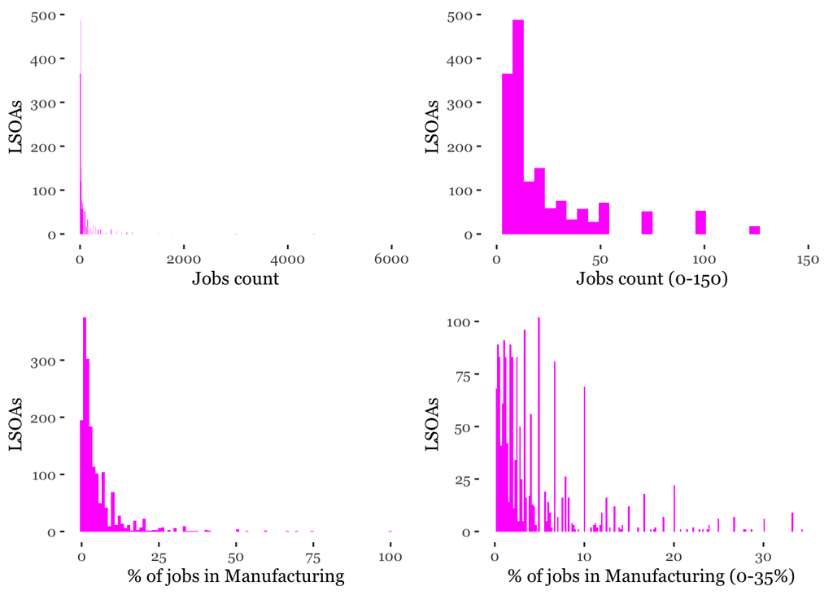

```r
# style
th <- theme_tufte(base_family = "Georgia")

h1 <- ggplot(nom1, aes(Count)) + geom_histogram(bins = 6000/5, fill="magenta") + th + ylab("LSOAs") + xlab("Jobs count")
h2 <- ggplot(nom1, aes(Count)) + geom_histogram(bins = 150/5, fill="magenta") + th + xlim(c(0, 150)) + ylab("LSOAs") + xlab("Jobs count (0-150)")
h3 <- ggplot(nom1, aes(`Industry percentage`)) + geom_histogram(bins = 100, fill="magenta") + th + ylab("LSOAs") + xlab("% of jobs in Manufacturing")
h4 <- ggplot(nom1, aes(`Industry percentage`)) + geom_histogram(bins = 200, fill="magenta") + th + xlim(c(0, 35)) + ylab("LSOAs") + xlab("% of jobs in Manufacturing (0-35%)")
grid.arrange(h1, h2, h3, h4, nrow=2)
```

## 4.4 Boxpolots

```r
fnC <- fivenum(nom1$Count)
fnP <- fivenum(nom1$`Industry percentage`)
```

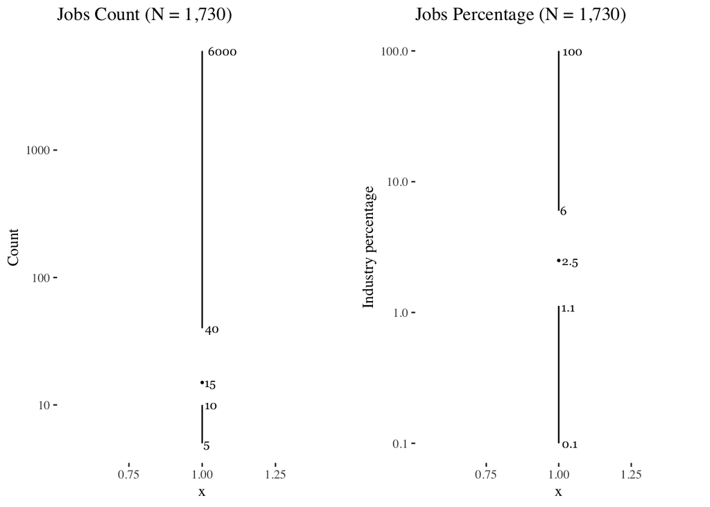

```r
anC <- annotate(geom="text", label=round(fnC ,digits=2), x= 1, y=fnC, size = 3, family = "Georgia", hjust =-.2)
anP <- annotate(geom="text", label=round(fnP ,digits=2), x= 1, y=fnP, size = 3, family = "Georgia", hjust =-.2)
th <- theme(axis.title=element_blank(),axis.ticks.x = element_blank(), axis.text.x=element_blank())

bC <- ggplot(nom1, aes(1, Count)) + geom_tufteboxplot() + scale_y_log10() + theme_classic() + anC +
  ggtitle("Jobs Count (N = 1,730)") + th + theme_tufte()
bP <- ggplot(nom1, aes(1, `Industry percentage`)) + geom_tufteboxplot() + scale_y_log10() + theme_classic() + anP  + ggtitle("Jobs Percentage (N = 1,730)") + th + theme_tufte()

grid.arrange(bC, bP, nrow=1)
```

## 4.5 Maps

```r
lsoa <- st_read("/Volumes/ritd-ag-project-rd00lq-jamfe87/GIS_Analysis/dataRaw/statistical-gis-boundaries-london/ESRI/LSOA_2011_London_gen_MHW.shp")
```

Join with NOMIS data ‘nom’

```r
mpl <- append_data(lsoa, nom, key.shp = "LSOA11CD", key.data = "lsoa11_cd", ignore.duplicates = TRUE, ignore.na = TRUE)
```

```
## Keys match perfectly.
```

```r
names(mpl)
```

```
##  [1] "LSOA11CD"            "LSOA11NM"            "MSOA11CD"
##  [4] "MSOA11NM"            "LAD11CD"             "LAD11NM"
##  [7] "RGN11CD"             "RGN11NM"             "USUALRES"
## [10] "HHOLDRES"            "COMESTRES"           "POPDEN"
## [13] "HHOLDS"              "AVHHOLDSZ"           "lsoa_2011"
## [16] "Count"               "Industry percentage" "geometry"
```

Maps of job Counts > 40 and Percentage > 6% (> 3rd Q)

```r
# change column name
colnames(mpl)[17] <- "IndPer"

c40 <- subset(mpl, Count >= 40) # 439 obs.
p6 <- subset(mpl, IndPer >= 6) # 434 obs.
# CP <- subset(mpl, Count >= 40 | IndPer >= 6)
```

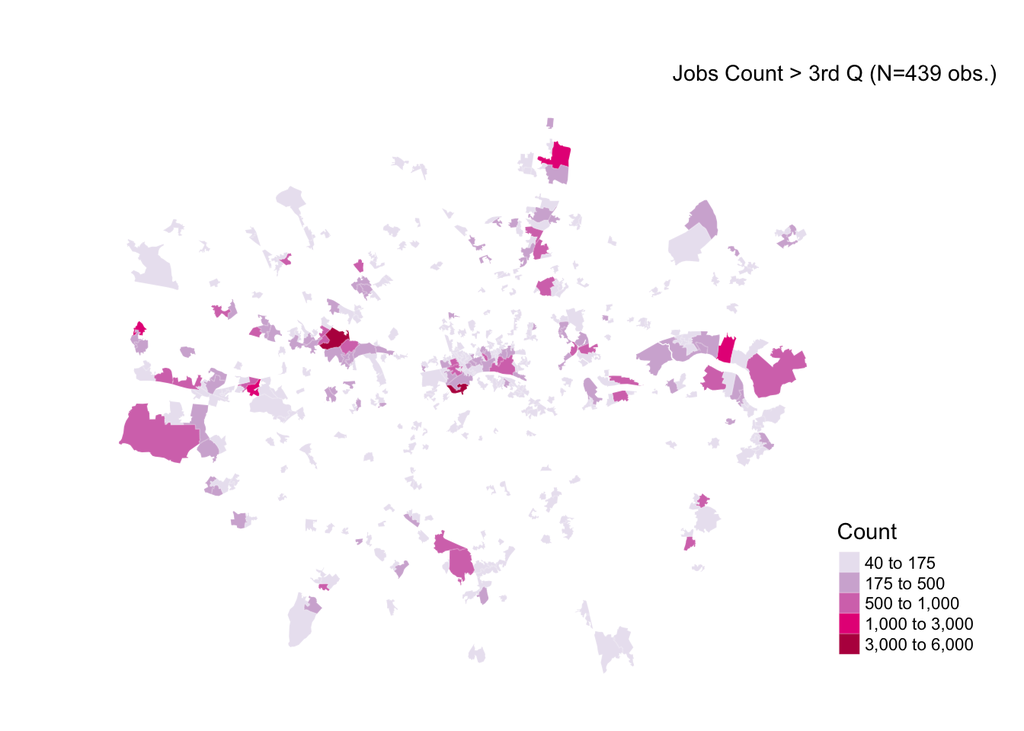

```r
mc40 <- tm_shape(c40) +
    tm_polygons("Count",
        style="jenks",
        palette="PuRd",
        title= "Count",
        border.col="white",
        border.alpha = 0.1) +
  tm_layout(inner.margins = c(0, 0.1, 0.05, 0.2), frame = F) +
  tm_legend(legend.position = c("right", "bottom"),
          main.title = "Jobs Count > 3rd Q (N=439 obs.)",
          main.title.position = "right",
          main.title.size=0.9)
mc40
```

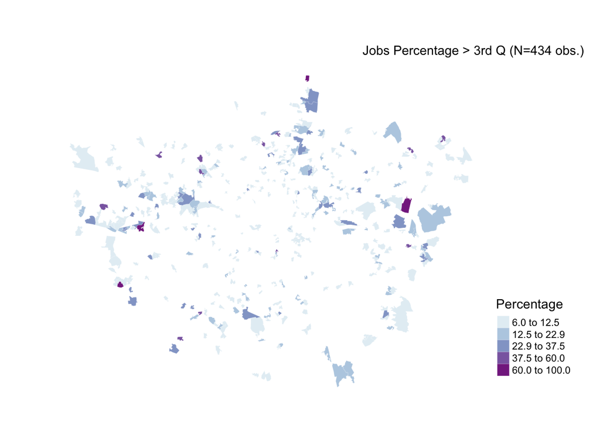

```r
mp6 <- tm_shape(p6) +
    tm_polygons("IndPer",
        style="jenks",
        palette="BuPu",
        title= "Percentage",
        border.col="white",
        border.alpha = 0.1) +
  tm_layout(inner.margins = c(0, 0.1, 0.05, 0.2), frame = F) +
  tm_legend(legend.position = c("right", "bottom"),
          main.title = "Jobs Percentage > 3rd Q (N=434 obs.)",
          main.title.position = "right",
          main.title.size=0.9)
mp6
```

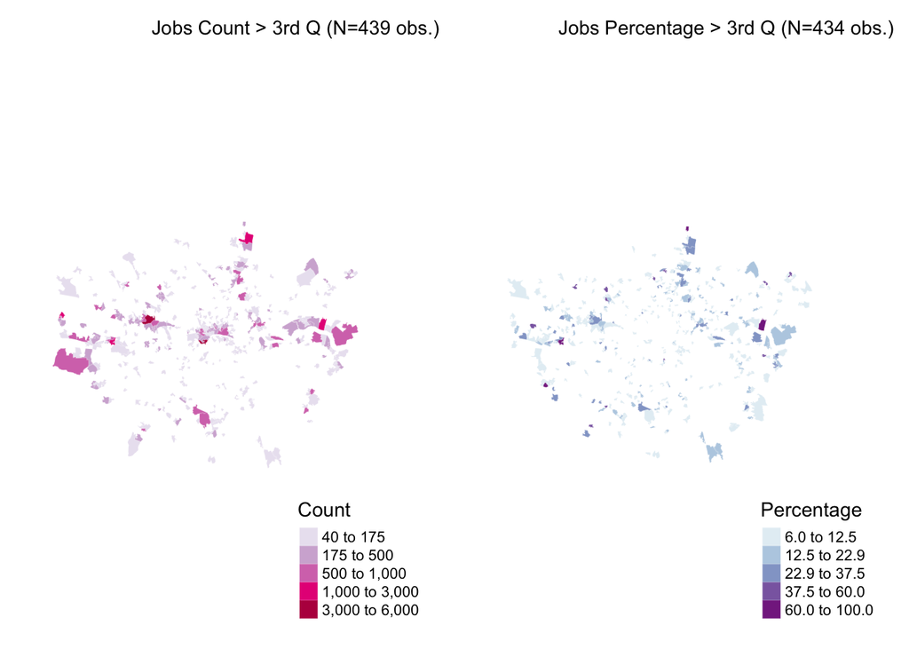

```r
tmap_arrange(mc40 ,mp6 , nrow=1)
```

```r
msum <- tm_shape(mpl) +
  tm_polygons(col="#ffffe5", border.col="#ededed", border.alpha = 0.01) +
  tm_shape(c40) +
  tm_polygons("Count",
              style="jenks",
              palette="BuPu",
              title="Jobs Count",
              border.col="white",
              border.alpha = 0.1) +
  tm_shape(p6) +
  tm_polygons(border.col = "magenta", border.alpha = 0.5, alpha = 0) +
  tm_layout(inner.margins = c(0, 0.1, 0.05, 0.2), frame = F)
```

```r
tmap_mode("plot")
```

```
## tmap mode set to plotting
```

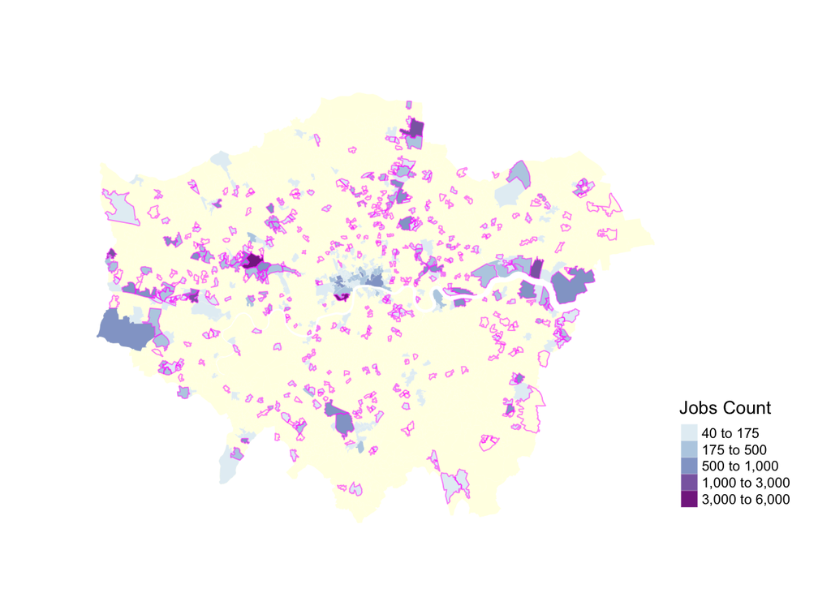

```r
msum
```

Select values with both conditions Count >= 40 & IndPer >= 6

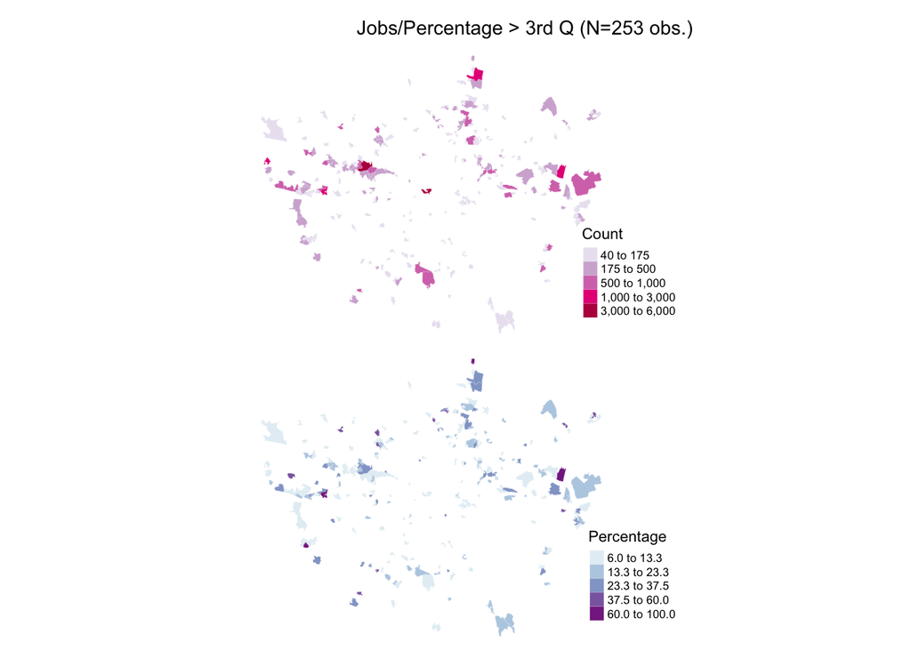

```r
CP <- subset(mpl, Count >= 40 & IndPer >= 6) # 253 obs.
mCP <- tm_shape(CP) +
    tm_polygons(c("Count",
                  "IndPer"),
        style="jenks",
        palette=list("PuRd","BuPu"),
        title=c("Count",
                "Percentage"),
        border.col="white",
        border.alpha = 0.1) +
  tm_layout(inner.margins = c(0, 0.1, 0.05, 0.2), frame = F) +
  tm_legend(legend.position = c("right", "bottom"),
          main.title = "Jobs/Percentage > 3rd Q (N=253 obs.)",
          main.title.position = "right",
          main.title.size=0.9)
mCP
```